```python
import numpy as np
import matplotlib.pyplot as plt
import pandas as pd
from sklearn.model_selection import KFold
```

# Question 1: Training and test error under a fixed design

```python
def question1(repetitions,n,p):
    """
    nsim : number of simulation
    n: number of sample
    p : number pf covariate
    """
    rng = np.random.default_rng(43202)

    #generate X_all data drawn from N(0,1) and intercept
    X = rng.normal(0, 1, size=(n, p))
    X_all = np.column_stack((np.ones(n), X))

    sigma = 1.0
    covariate_count = np.arange(p + 1)

    #let β_j=0.4j
    beta = np.zeros(p + 1)
    beta[1:] = 0.4 ** np.sqrt(np.arange(1, p + 1))

    mu = X_all @ beta

    train_mse_decay = np.empty((repetitions, p+1))
    test_mse_decay = np.empty((repetitions, p+1))
    for re in range(repetitions):
        ## genenrate training and test reponse
        y_train = mu + rng.normal(loc=0.0, scale=sigma, size=n)
        y_test = mu + rng.normal(loc=0.0, scale=sigma, size=n)
        ## fit for the intercep model
        y_hat = np.repeat(y_train.mean(), n)
        train_mse_decay[re, 0] = np.mean((y_train - y_hat) ** 2)
        test_mse_decay[re, 0] = np.mean((y_test - y_hat) ** 2)
        for m in range(1, p+1):
            X_m = X_all[:, :m+1]
            beta_hat = np.linalg.lstsq(X_m, y_train, rcond=None)[0]
            y_hat = X_m @ beta_hat
            train_mse_decay[re, m] = np.mean((y_train - y_hat) ** 2)
            test_mse_decay[re, m] = np.mean((y_test - y_hat) ** 2)



    bias_mse_decay = np.empty(p + 1)
    bias_mse_decay[0] = np.mean((mu - (mu).mean()) ** 2)

    for m in range(1, p + 1):
        X_m = X_all[:, :m + 1]
        beta_hat = np.linalg.lstsq(X_m, mu, rcond=None)[0]
        y_hat = X_m @ beta_hat
        bias_mse_decay[m] = np.mean((mu - y_hat) ** 2)

    theory_train_mse_decay = bias_mse_decay + (1 - (covariate_count + 1) / n) * sigma**2
    theory_test_mse_decay = bias_mse_decay + (1 + (covariate_count + 1) / n) * sigma**2
    return train_mse_decay,test_mse_decay,theory_train_mse_decay,theory_test_mse_decay
```

```python
train_mse,test_mse,expected_train_mse,expected_test_mse = question1(200,100,20)
```

```python
def plot_question_result(train_mse,test_mse,expected_train_mse_train_mse,expected_test_mse):
    fig,axs = plt.subplots(1,2,figsize=(10,5))
    for ax_id,ax in enumerate(axs.flat):
        ax.set_box_aspect(1)
        ax.set_xlabel("Number of covariates")
        ax.set_ylabel("Mean squared error")

        if ax_id ==0:
            mean_train_mse_decay = train_mse.mean(axis=0)
            mean_test_mse_decay = test_mse.mean(axis=0)
            ax.plot(np.arange(1,train_mse.shape[1]+1),mean_train_mse_decay,color="#E69F00",lw=3,label="Average training MSE")
            ax.plot(np.arange(1,train_mse.shape[1]+1),expected_train_mse,color="#E69F00",lw=3,label="Expected training MSE",ls=":")
            ax.plot(np.arange(1,train_mse.shape[1]+1),mean_test_mse_decay,color="#56B4E9",lw=3,label="Average test MSE")
            ax.plot(np.arange(1,train_mse.shape[1]+1),expected_test_mse,color="#56B4E9",lw=3,label="Expected test MSE",ls=":")
            ax.legend(loc="best")
        else:
            ax.plot(np.arange(1,train_mse.shape[1]+1),test_mse[5],color="#E69F00",lw=3,label="Test MSE curve for a single run")
            ax.legend(loc="best")
```

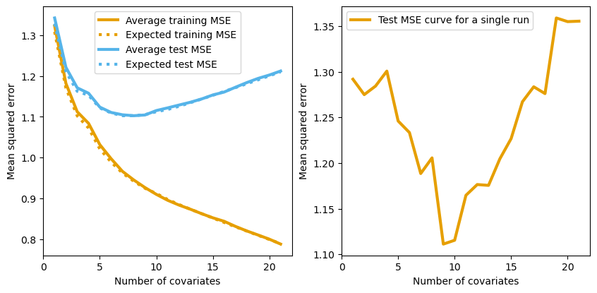

```python
plot_question_result(train_mse,test_mse,expected_train_mse,expected_test_mse)
```

c.1 Random noise fluctuations are averaged out in the average curve, but a single run preserves the random variation inherent in a single response vector.

c.2 $$ E(\text{MSE}_{\text{train}} \mid X) = \frac{B^2}{n} + \left(1 - \frac{p}{n}\right)\sigma^2 $$ where:

- $B^2$ is the sum of squared model biases (i.e., the sum of squared differences between the fitted function and the true function; if the model is correctly specified, then $B^2 = 0$);
- $p$ the total number of model parameters;
- $n$ is the sample size;
- $\sigma^2$ is the variance of the error term. As the number of predictors $p$ increases:

(1) The variance term $\left(1 - \frac{p}{n}\right)\sigma^2$ monotonically decreases (because $1 - \frac{p}{n}$ becomes smaller).

(2) The bias term $\frac{B^2}{n}$ does not increase, since adding more variables may capture additional true signal, and even if they are not, the bias at least remains unchanged.

# Question 2: Prediction error at one target point

```python
def question2(repetitions, n,p):
    sigma = 1.0
    rng = np.random.default_rng(43203)
    i = np.arange(1, n + 1)[:, None]
    j = np.arange(1, p + 1)[None, :]
    X_all = np.sqrt(2) * np.cos(np.pi * j * (i - 0.5) / n)
    beta = np.array([0.5,0.5,0.5,0.5,0.5,0.5],dtype=float)
    x0 = np.array([0,1,0,0,1,0])

    mu = X_all @ beta
    mu0 = x0 @ beta

    simulation_error = np.empty((repetitions, p + 1))

    for k in range(repetitions):
        y_train = mu + rng.normal(size=n)
        for m in range(p + 1):
            X_m = np.column_stack((np.ones(n), X_all[:, :m]))
            beta_hat = np.linalg.lstsq(X_m, y_train, rcond=None)[0]
            target_row = np.r_[1, x0[:m]]
            mu0_hat = target_row @ beta_hat
            simulation_error[k, m] = (mu0_hat - mu0) ** 2
    simulated = simulation_error.mean(axis=0)
    theoretical = np.empty(p + 1)


    for m in range(p + 1):
        omitted = x0[m:] @ beta[m:]
        est_var = sigma**2 * (1 + np.sum(x0[:m] ** 2)) / n
        theoretical[m] = omitted**2 + est_var
        print("m = %d  simulated = %.4f  theoretical = %.4f"
              % (m, simulated[m], theoretical[m]))
    fig,ax = plt.subplots(1,1)
    ax.plot(np.arange(p + 1),simulated,"#E69F00",label = "Simulated")
    ax.plot(np.arange(p + 1),theoretical,label = "Theoretical")
    ax.legend(loc="best")
    ax.set_xlabel("Number of covariates")
    ax.set_ylabel("Mean squared error at the target")
```

```
m = 0  simulated = 0.9839  theoretical = 1.0100
m = 1  simulated = 0.9839  theoretical = 1.0100
m = 2  simulated = 0.2464  theoretical = 0.2700
m = 3  simulated = 0.2464  theoretical = 0.2700
m = 4  simulated = 0.2464  theoretical = 0.2700
m = 5  simulated = 0.0237  theoretical = 0.0300
m = 6  simulated = 0.0237  theoretical = 0.0300
```

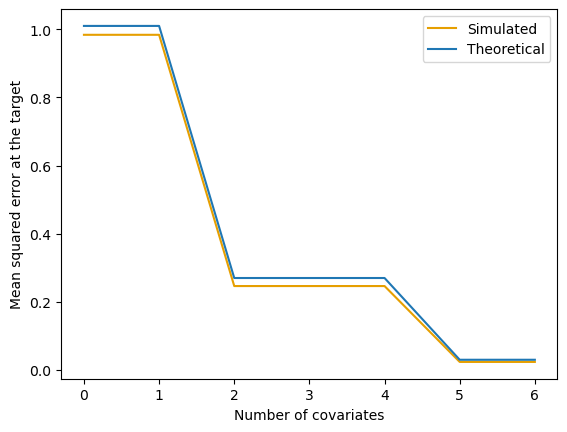

```python
question2(200,100,6)
```

a. The expected squared error equals the squared bias plus the variance. The bias arises because model m omits the last p−m predictors and so fails to fit their contributions at the target point; the variance arises because the m+1 coefficients must be estimated from noisy data, and this estimation uncertainty is propagated to the prediction through x₀.

b. Smallest m that minimizes the theoretical error is 5.

c. Only predictors 2 and 5 influence μ₀ because they are the only coordinates where x₀ is nonzero, whereas Question 1's test MSE averages over all rows so every predictor contributes.

# Question 3: The optimism correction

## 1. Derive Expected Training MSE, Expected Test MSE, and the Expected Optimism

### (1) Expected Training MSE

We have

$$ \begin{aligned} \boldsymbol{y} - \boldsymbol{H}\boldsymbol{y} &= \boldsymbol{\mu} + \boldsymbol{\epsilon} - \boldsymbol{H}(\boldsymbol{\mu} + \boldsymbol{\epsilon}) \\ &= (\boldsymbol{I}_n - \boldsymbol{H})\boldsymbol{\mu} + (\boldsymbol{I}_n - \boldsymbol{H})\boldsymbol{\epsilon}. \end{aligned} $$

Taking the squared norm and expectation, the cross term

$$ 2(\boldsymbol{I}_n-\boldsymbol{H})\boldsymbol{\mu} \cdot (\boldsymbol{I}_n-\boldsymbol{H})\boldsymbol{\epsilon} $$

has zero expectation because

$$ E(\boldsymbol{\epsilon}\mid\boldsymbol{X})=0. $$

Thus,

$$ \begin{aligned} E(\mathrm{MSE}_{\mathrm{train}}\mid\boldsymbol{X}) &= \frac{1}{n} \left[ \left\| (\boldsymbol{I}_n-\boldsymbol{H})\boldsymbol{\mu} \right\|^2 + E\left( \boldsymbol{\epsilon}^{\top} (\boldsymbol{I}_n-\boldsymbol{H}) \boldsymbol{\epsilon} \right) \right] \\ &= \frac{B^2}{n} + \frac{\sigma^2}{n} \operatorname{tr}(\boldsymbol{I}_n-\boldsymbol{H}) \\ &= \frac{B^2}{n} + \frac{\sigma^2}{n} \left(n-(p+1)\right) \\ &= \boxed{ \frac{B^2}{n} + \sigma^2 \left( 1-\frac{p+1}{n} \right) }. \end{aligned} $$

### (2) Expected Test MSE

We have

$$ \begin{aligned} \boldsymbol{y}^*-\boldsymbol{H}\boldsymbol{y} &= \boldsymbol{\mu}+\boldsymbol{\epsilon}^* - \boldsymbol{H}(\boldsymbol{\mu}+\boldsymbol{\epsilon}) \\ &= (\boldsymbol{I}_n-\boldsymbol{H})\boldsymbol{\mu} + \boldsymbol{\epsilon}^* - \boldsymbol{H}\boldsymbol{\epsilon}. \end{aligned} $$

All cross terms have zero expectation because $\boldsymbol{\epsilon}$ and $\boldsymbol{\epsilon}^*$ are independent and have mean zero.

Thus,

$$ \begin{aligned} E(\mathrm{MSE}_{\mathrm{test}}\mid\boldsymbol{X}) &= \frac{1}{n} \left[ B^2 + E\left(\|\boldsymbol{\epsilon}^*\|^2\right) + E\left( \|\boldsymbol{H}\boldsymbol{\epsilon}\|^2 \right) \right] \\ &= \frac{B^2}{n} + \frac{n\sigma^2}{n} + \frac{\sigma^2\operatorname{tr}(\boldsymbol{H})}{n} \\ &= \frac{B^2}{n} + \sigma^2 + \frac{(p+1)\sigma^2}{n} \\ &= \boxed{ \frac{B^2}{n} + \sigma^2 \left( 1+\frac{p+1}{n} \right) }. \end{aligned} $$

### (3) Expected Optimism

The expected optimism is

$$ \begin{aligned} E( \mathrm{MSE}_{\mathrm{test}} - \mathrm{MSE}_{\mathrm{train}} \mid\boldsymbol{X} ) &= \left( 1+\frac{p+1}{n} \right)\sigma^2 - \left( 1-\frac{p+1}{n} \right)\sigma^2 \\ &= \boxed{ \frac{2(p+1)\sigma^2}{n} }. \end{aligned} $$

## 2. Numerical Computation for $n=120$, $p=4$, $\frac{B^2}{n}=0.04$, and $\sigma^2=1$

Here,

$$ p+1=5. $$

### Expected Training MSE

$$ \begin{aligned} E(\mathrm{MSE}_{\mathrm{train}}) &= 0.04+ \left( 1-\frac{5}{120} \right)\times 1 \\ &= 0.04+\frac{115}{120} \\ &= 0.04+0.9583 \\ &= \boxed{0.9983}. \end{aligned} $$

### Expected Test MSE

$$ \begin{aligned} E(\mathrm{MSE}_{\mathrm{test}}) &= 0.04+ \left( 1+\frac{5}{120} \right)\times 1 \\ &= 0.04+\frac{125}{120} \\ &= 0.04+1.0417 \\ &= \boxed{1.0817}. \end{aligned} $$

### Expected Difference (Optimism)

$$ \begin{aligned} E( \mathrm{MSE}_{\mathrm{test}} - \mathrm{MSE}_{\mathrm{train}} ) &= \frac{2\times5\times1}{120} \\ &= \frac{10}{120} \\ &= \boxed{0.0833}. \end{aligned} $$

### Why the Ordering Need Not Hold for Every Realized Pair

The above values are **expectations**, meaning they are averages over many repeated samples.

For a single realized pair of training and test responses:

- The training noise $\boldsymbol{\epsilon}$ might be unusually small, making the realized training MSE much lower than its expectation.
- The test noise $\boldsymbol{\epsilon}^*$ might be unusually large, making the realized test MSE much higher than its expectation.
- It is therefore possible that, for one particular realization,

$$ \mathrm{MSE}_{\mathrm{train}} > \mathrm{MSE}_{\mathrm{test}}. $$

Only after averaging over many realizations does the positive expected optimism

$$ \frac{2(p+1)\sigma^2}{n} $$

become apparent.

## 3. Given $n=120$, $p=4$, $\mathrm{RSS}=116.4$, and $\hat{\sigma}^2=0.96$

We have

$$ p+1=5. $$

### (1) Corrected Test MSE

The corrected estimate of the test MSE is

$$ \begin{aligned} \widehat{\mathrm{MSE}}_{\mathrm{test}} &= \frac{ \mathrm{RSS} + 2(p+1)\hat{\sigma}^2 }{n} \\ &= \frac{ 116.4 + 2\times5\times0.96 }{120} \\ &= \frac{116.4+9.6}{120} \\ &= \frac{126.0}{120} \\ &= \boxed{1.05}. \end{aligned} $$

### (2) Mallows' $C_p$

Mallows' $C_p$ is

$$ C_p = \frac{\mathrm{RSS}}{\hat{\sigma}^2} - n + 2(p+1). $$

Substituting the given values,

$$ \begin{aligned} C_p &= \frac{116.4}{0.96} - 120 + 10 \\ &= 121.25-120+10 \\ &= \boxed{11.25}. \end{aligned} $$

### (3) Relationship Between $\widehat{\mathrm{MSE}}_{\mathrm{test}}$ and $C_p$

Starting from the corrected test MSE,

$$ \widehat{\mathrm{MSE}}_{\mathrm{test}} = \frac{ \mathrm{RSS} + 2(p+1)\hat{\sigma}^2 }{n}. $$

Multiply both sides by $\frac{n}{\hat{\sigma}^2}$:

$$ \begin{aligned} \frac{n}{\hat{\sigma}^2} \widehat{\mathrm{MSE}}_{\mathrm{test}} &= \frac{ \mathrm{RSS} + 2(p+1)\hat{\sigma}^2 }{\hat{\sigma}^2} \\ &= \frac{\mathrm{RSS}}{\hat{\sigma}^2} + 2(p+1). \end{aligned} $$

Now recall that

$$ C_p = \frac{\mathrm{RSS}}{\hat{\sigma}^2} - n + 2(p+1). $$

Therefore,

$$ \begin{aligned} C_p &= \left( \frac{\mathrm{RSS}}{\hat{\sigma}^2} + 2(p+1) \right) - n \\ &= \frac{n}{\hat{\sigma}^2} \widehat{\mathrm{MSE}}_{\mathrm{test}} - n. \end{aligned} $$

Hence,

$$ \boxed{ C_p = \frac{n}{\hat{\sigma}^2} \widehat{\mathrm{MSE}}_{\mathrm{test}} - n }. $$

Equivalently,

$$ \boxed{ \widehat{\mathrm{MSE}}_{\mathrm{test}} = \frac{\hat{\sigma}^2}{n} (C_p+n) }. $$

### (4) Why Minimizing $C_p$ Is Equivalent to Minimizing the Corrected Test MSE

When comparing a set of candidate models:

- $n$ is the same for all candidate models.
- $\hat{\sigma}^2$ is the same common estimate of the error variance for all candidate models.

Therefore,

$$ \frac{\hat{\sigma}^2}{n} $$

is a positive constant across all candidate models.

From

$$ \widehat{\mathrm{MSE}}_{\mathrm{test}} = \frac{\hat{\sigma}^2}{n} (C_p+n), $$

we can see that $\widehat{\mathrm{MSE}}_{\mathrm{test}}$ is a positive linear transformation of $C_p$.

Adding the constant $n$ and multiplying by the positive constant $\frac{\hat{\sigma}^2}{n}$ do not change the ordering of the candidate models.

Therefore,

$$ \boxed{ \arg\min C_p = \arg\min \widehat{\mathrm{MSE}}_{\mathrm{test}} }. $$

In other words:

> **The model that minimizes Mallows' $C_p$ also minimizes the corrected estimate of the test MSE.**

This is the mathematical justification for using Mallows' $C_p$ as a model selection criterion.

# Question 4: Comparing Mallows’ C$_{p}$, AIC, and BIC

```python
def question4():
    def fit_ols_rss(var,data):
        X = np.column_stack((np.ones(n),data[var].values))
        beta_hat = np.linalg.lstsq(X, data["y"].values, rcond=None)[0]
        y_hat = X @ beta_hat
        Rss = np.sum((data["y"].values - y_hat)**2)
        return Rss

    data = pd.read_csv("../data/diabetes.csv").iloc[:370]
    n = data.shape[0]
    variable_A = ["bmi", "bp", "s5", "sex", "s1", "s2", "s4"]
    variable_B = ["bmi", "bp", "s5", "sex", "s1", "s2", "s4","s6"]
    variable_full = ['age', 'sex', 'bmi', 'bp', 's1', 's2', 's3', 's4', 's5', 's6']
    ##a
    print ("a")
    rss_a = fit_ols_rss(variable_A,data)
    print ("Model A: p = %d, RSS = %.2f"%(len(variable_A),rss_a))
    rss_b = fit_ols_rss(variable_B,data)
    print ("Model B: p = %d, RSS = %.2f"%(len(variable_B),rss_b))
    rss_full = fit_ols_rss(variable_full,data)
    residual_df = n - (len(variable_full) + 1)
    sigma2_hat = rss_full / residual_df
    print ("Model Full: p = %d, RSS = %.2f, residual_df = %.2f, sigma2_hat = %.2f"%(len(variable_full),rss_full,residual_df,sigma2_hat))
    ##b
    def crit(rss_val, p_val):
        cp   = rss_val / sigma2_hat - n + 2 * (p_val + 1)
        aic  = n * np.log(rss_val / n) + 2 * (p_val + 1)
        bic  = n * np.log(rss_val / n) + np.log(n) * (p_val + 1)
        return cp, aic, bic
    print("\nb")
    for name, rss_val, p_val in [
        ("A", rss_a, len(variable_A)),
        ("B", rss_b, len(variable_B)),
    ]:
        cp, aic, bic = crit(rss_val, p_val)
        print("Model %s: Cp = %.4f, AIC = %.4f, BIC = %.4f"
              % (name, cp, aic, bic))
    ##c
    print("\nc.1")
    fit_gain = n * np.log(rss_a / rss_b)
    cp_gain  = (rss_a - rss_b) / sigma2_hat
    print("fit_gain (AIC/BIC) = %.4f" % fit_gain)
    print("cp_gain = %.4f" % cp_gain)
    print("AIC penalty = 2, Cp penalty = 2, BIC penalty = log(n) = %.4f" % np.log(n))
```

```python
question4()
```

```
a
Model A: p = 7, RSS = 1098908.57
Model B: p = 8, RSS = 1089717.06
Model Full: p = 10, RSS = 1089451.72, residual_df = 359.00, sigma2_hat = 3034.68

b
Model A: Cp = 8.1163, AIC = 2974.6403, BIC = 3005.9483
Model B: Cp = 7.0874, AIC = 2973.5325, BIC = 3008.7540

c.1
fit_gain (AIC/BIC) = 3.1078
cp_gain = 3.0288
AIC penalty = 2, Cp penalty = 2, BIC penalty = log(n) = 5.9135
```

c.2 Adding `s6` reduces the fit term by n*log(RSS_A / RSS_B) = 3.108 on the AIC/BIC scale, and by (RSS_A - RSS_B) / sigma2_hat = 3.029 on the Cp scale. AIC and Cp charge a penalty of only 2 for the one extra parameter, so the improvement (3.108 > 2, and 3.029 > 2) outweighs the penalty, and they select Model B. BIC, however, charges log(n) = log(370) = 5.914 for that same extra parameter. Since 3.108 < 5.914, the improvement does not cover the penalty, so BIC keeps the simpler Model A. The disagreement therefore comes entirely from the different penalties: AIC and Cp penalize lightly (2), while BIC penalizes more heavily (log n).

c.3 Selecting a model only ranks a small set of candidate models under a particular criterion. It chooses the best model among those candidates, not the model that actually generated the data. The true data-generating model may not be in the candidate set at all, or it may involve omitted variables, nonlinearities, or interactions that none of the fitted candidates contain. Model selection is therefore a relative comparison, not a proof of the truth.

# Question 5: Validation and final test data

a. Step 2 is the first misuse. Although the coefficients are fitted using only the training data, Steps 2-3 use the final test responses to compare and select among the candidate models. The test set therefore participates in model selection, so it is no longer an untouched final evaluation.

b. Each of the eleven test MSEs contains random variation. Taking the minimum tends to pick the model whose test MSE happened to be unusually small by chance. Reporting that same minimum as the final estimate is then overly optimistic: the number has already been "cherry-picked" from the eleven values, so it underestimates the true prediction error of the selected procedure.

c. A valid procedure is:

1. Reserve rows 371-442 as the final test set and do not inspect their responses.
2. Divide rows 1-370 into five folds.
3. For each candidate predictor count m, train on four folds and compute the MSE on the remaining fold; repeat until every fold has served as the validation fold.
4. Average the five validation MSEs for each m and select the m with the smallest average.
5. Refit the selected model using all 370 training observations.
6. Evaluate this fitted model once, only at the end, on rows 371-442.

```python
def question5():
    data = pd.read_csv("../data/diabetes.csv")

    train = data.iloc[:370]
    n_train = train.shape[0]
    test = data.iloc[370:]
    variable_full = ['age', 'sex', 'bmi', 'bp', 's1', 's2', 's3', 's4', 's5', 's6']
    kf = KFold(n_splits=5, shuffle=False)
    cv_mse = np.zeros(len(variable_full)+1)

    for m in range(len(variable_full)):
        varss = variable_full[:m]
        Xm = np.column_stack((np.ones(n_train), train[varss]))
        fold_mse = []
        for tr_idx, va_idx in kf.split(Xm):
            beta = np.linalg.lstsq(Xm[tr_idx], train["y"].values[tr_idx], rcond=None)[0]
            pred = Xm[va_idx] @ beta
            fold_mse.append(np.mean((train["y"].values[va_idx] - pred) ** 2))
        cv_mse[m] = np.mean(fold_mse)
    m_best = int(np.argmin(cv_mse))
```

[output not shown]

```python
question5()
```